# Entrega grupal

Pablo Gómez (DNI:03214857D)

Wenxiang Xia (DNI:X2726507C)

Javier Figueiredo (DNI:06341629T)

Cyan Morales (DNI:02780780B)

## Paquetes necesarios

```r
rm(list = ls())
library(tidyverse)
library(dplyr)
library(glue)
library(ggplot2)
library(lubridate)
library(forcats)
library(patchwork)
library(ggtext)
library(ggnewscale)
library(waffle)
library(camcorder)
library(showtext)
library(sysfonts)
library(ineAtlas)
library(ggThemeAssist)
library(patchwork)
```

### Datos

La práctica se basará en los **archivos de datos electorales**

```r
# NO TOQUES NADA
election_data <- read_csv(file = "./data/datos_elecciones_brutos.csv")
cod_mun <- read_csv(file = "./data/cod_mun.csv")
surveys <- read_csv(file = "./data/historical_surveys.csv")
abbrev <- read_csv(file = "./data/siglas.csv")
```

### Convirtiendo los datos a tidydata.

```r
# abbrev, cod_mun ya están en formato tidydata.

# election_data y surveys no están en formato tidydata ya que en cada fila nos encontramos con los votos en cada municipio para todos los partidos. Una fila solo debe contener una única observación.
election_data <-
  election_data |>
  pivot_longer(cols = -c(tipo_eleccion:votos_candidaturas),
               names_to = "partidos", values_to = "votos",
               values_drop_na = TRUE) |>
  mutate(across(where(is.logical), as.numeric))
surveys <-
  surveys |>
  pivot_longer(cols = -c(type_survey:turnout),
               names_to = "partido", values_to = "puntuacion",
               values_drop_na = TRUE) |>
  mutate(across(where(is.logical), as.numeric))
```

### Información = Varianza: Eliminando columnas con un único valor.

```r
# vemos primero cantidad de valores únicos en cada una
election_data_dist <- election_data |> summarise(across(everything(), n_distinct))
cod_mun_dist <- cod_mun |> summarise(across(everything(), n_distinct))
surveys_dist <- surveys |> summarise(across(everything(), n_distinct))
abbrev_dist <- abbrev |> summarise(across(everything(), n_distinct))

# Eliminamos las columnas en las que su valor es el mismo siempre

election_data <-
  election_data |>
  select(-c(tipo_eleccion, vuelta, codigo_distrito_electoral))
surveys <- surveys |> select(-type_survey)
```

### Siglas de los partidos políticos.

```r
election_data <-
  election_data |>
  mutate("siglas" = case_when(
str_detect(partidos, "SOCIALISTA|SOCIALISTES")~ "PSOE",
str_detect(partidos, "PARTIDO POPULAR|PP") ~ "PP",
str_detect(partidos, "CIUDADANOS|CIUDADANÍA|CIUDADANIA|CIUTADANS") ~ "CS",
str_detect(partidos, "PARTIDO NACIONALISTA VASCO") ~ "PNV",
str_detect(partidos, "BLOQUE NACIONALISTA GALEGO") ~ "BNG",
str_detect(partidos, "PODEMOS|IZQUIERDA UNIDA") ~ "UP",
str_detect(partidos, "ESQUERRA REPUBLICANA DE CAT") ~ "ERC",
str_detect(partidos, "SORTU|EUSKO ALKARTASUNA|ARALAR|ALTERNATIBA")~"BILDU",
str_detect(partidos, "MÁS PAÍS|MAS PAIS|MÁS PAIS|MAS PAÍS") ~ "MP",
str_detect(partidos, "VOX") ~ "VOX",
str_detect(partidos,"CONVERGÈNCIA I UNIÓ")~"CiU",
TRUE ~ "OTROS"))
```

### Filtrado de encuestas

```r
surveys <- surveys |>
  filter(
    as.numeric(format(date_elec, "%Y")) >= 2008,  # Elecciones desde 2008
    exit_poll == FALSE,                           # No sean a pie de urna
    !is.na(size) & size >= 500,                   # Tamaño muestral conocido y >= 500
    field_date_to - field_date_from > 1 # Más de 1 día de trabajo de campo
  )
```

### ¿Qué partido fue el ganador en los municipios con más de 100.000 habitantes (censo) en cada una de las elecciones?

```r
# Creo un identificador único por municipio y por elección
election_data <- election_data |>
  mutate(
    id_mun = (glue("{codigo_ccaa}-{codigo_provincia}-{codigo_municipio}")),
    fecha = (as_date(glue("{anno}-{mes}-01")))
  )  |>
  select(-c(anno,mes,codigo_ccaa,codigo_provincia,codigo_municipio)) |>
  select(fecha, id_mun, everything())

# Filtrar municipios con más de 100,000 habitantes
# Encontrar el partido ganador usando summarise y max
ganadores <- election_data |>
  filter(censo >= 100000) |>
  group_by(id_mun, fecha) |>
  slice_max(order_by = votos, n = 1) |>  # Máximo voto por grupo
  ungroup() |>
  select(id_mun, fecha, siglas, votos,censo)

#Inner join para saber el nombre del municipio
ganadores <- ganadores |>
  inner_join(cod_mun, by = c("id_mun"="cod_mun"))
```

### ¿Qué partido fue el ganador en los municipios con más de 100.000 habitantes (censo) en cada una de las elecciones?

```r
ganadores
```

```
# A tibble: 282 × 6
   id_mun    fecha      siglas votos  censo municipio
   <glue>    <date>     <chr>  <dbl>  <dbl> <chr>
 1 01-04-013 2008-03-01 PP     49463 134948 Almería
 2 01-04-013 2011-11-01 PP     53152 137458 Almería
 3 01-04-013 2015-12-01 PP     34111 141116 Almería
 4 01-04-013 2016-06-01 PP     38809 141380 Almería
 5 01-04-013 2019-04-01 PSOE   29499 143323 Almería
 6 01-04-013 2019-11-01 PSOE   26715 143819 Almería
 7 01-11-012 2008-03-01 PSOE   32798 106478 Cádiz
 8 01-11-012 2011-11-01 PP     32960 103946 Cádiz
 9 01-11-012 2015-12-01 PP     21502 100460 Cádiz
10 01-11-020 2008-03-01 PSOE   55811 158933 Jerez de la Frontera
# ℹ 272 more rows
```

### ¿Qué partido fue el segundo cuando el primero fue el PSOE? ¿Y cuando el primero fue el PP?

```r
obtener_segundo_partido <- function(election_data, partido_primero) {
  election_data |>
    group_by(fecha, id_mun) |>
    arrange(desc(votos)) |>
    mutate(ranking = row_number()) |>
    filter(ranking == 1 & siglas == partido_primero) |>
    left_join(
      election_data |>
        group_by(fecha, id_mun) |>
        arrange(desc(votos)) |>
        mutate(ranking = row_number()) |>
        filter(ranking == 2) |>
        select(fecha, id_mun, siglas_segundo = siglas, votos_segundo = votos),
      by = c("fecha", "id_mun")
    ) |>
    select(fecha, id_mun,siglas_primero = siglas, votos_primero = votos,
           siglas_segundo, votos_segundo)}

# Uso de la función
resultado_PSOE <- obtener_segundo_partido(election_data, "PSOE")
resultado_PP <- obtener_segundo_partido(election_data, "PP")
```

### ¿Qué partido fue el segundo cuando el primero fue el PSOE?

```r
resultado_PSOE
```

```
# A tibble: 14,679 × 6
# Groups:   fecha, id_mun [14,679]
   fecha      id_mun   siglas_primero votos_primero siglas_segundo votos_segundo
   <date>     <glue>   <chr>                  <dbl> <chr>                  <dbl>
 1 2019-04-01 12-28-0… PSOE                  502909 PP                    389751
 2 2008-03-01 09-08-0… PSOE                  356264 OTROS                 171815
 3 2008-03-01 01-41-0… PSOE                  209515 PP                    153839
 4 2008-03-01 02-50-2… PSOE                  173636 PP                    139097
 5 2008-03-01 01-29-0… PSOE                  135722 PP                    133046
 6 2019-04-01 01-41-0… PSOE                  133592 PP                     72179
 7 2019-11-01 01-41-0… PSOE                  122475 PP                     84000
 8 2019-04-01 02-50-2… PSOE                  119436 CS                     84272
 9 2019-04-01 17-46-2… PSOE                  113237 CS                     84956
10 2019-11-01 02-50-2… PSOE                  108977 PP                     84006
# ℹ 14,669 more rows
```

### ¿Y cuando el primero fue el PP?

```r
resultado_PP
```

```
# A tibble: 25,634 × 6
# Groups:   fecha, id_mun [25,634]
   fecha      id_mun   siglas_primero votos_primero siglas_segundo votos_segundo
   <date>     <glue>   <chr>                  <dbl> <chr>                  <dbl>
 1 2008-03-01 12-28-0… PP                    919701 PSOE                  691580
 2 2011-11-01 12-28-0… PP                    880723 PSOE                  438654
 3 2016-06-01 12-28-0… PP                    696804 UP                    367526
 4 2015-12-01 12-28-0… PP                    646348 UP                    376283
 5 2019-11-01 12-28-0… PP                    479448 PSOE                  463364
 6 2008-03-01 17-46-2… PP                    246911 PSOE                  175725
 7 2011-11-01 17-46-2… PP                    226404 PSOE                  103103
 8 2011-11-01 01-41-0… PP                    169938 PSOE                  139519
 9 2011-11-01 02-50-2… PP                    162977 PSOE                  104287
10 2016-06-01 17-46-2… PP                    159079 UP                    119236
# ℹ 25,624 more rows
```

### ¿A quién beneficia la baja participación?

```r
participacion <-
  election_data |>
  mutate("votos_totales" = votos_candidaturas + votos_blancos + votos_nulos, "participacion" = 100 * votos_totales / censo) |> # Calcular el porcentaje de participación
  group_by(fecha, id_mun, siglas, votos_totales, participacion) |> # Agrupar para sumar los valores repetidos de OTROS
  summarize(votos = sum(votos), .groups = "drop") |>
  mutate("porcentaje_votos" = votos / votos_totales) |>
  select(-votos, -votos_totales)

corr_participacion <-
  participacion |>
  group_by(siglas) |>
  summarize(correlacion = cor(participacion, porcentaje_votos, use = "complete.obs")) |>
  arrange(correlacion)

# Cuanto menor es el valor de correlación, más se beneficia los votos del partido por la baja participacion.

# Gráficos
ggplot(corr_participacion, aes(x = reorder(siglas, correlacion), y = correlacion, fill= siglas)) +
  geom_bar(stat = "identity", show.legend = FALSE) +  # Bar chart
  scale_fill_manual(values= c(CS = "orange",UP = "purple",
                              VOX = "green",OTROS="grey",
                              MP="#009975", BNG="#6AADE4", PNV="#086522",
                              CiU="#FFDFC4", ERC="yellow",BILDU="#30D5C8",
                              PSOE="red", PP="blue"))+
  coord_flip() +  # Flip coordinates for horizontal bars
  labs(
    title = "Correlación entre baja participación y resultados para cada partido",
    x = "Partido (siglas)",
    y = "Correlación"
  ) +
  theme_minimal()
```

### ¿A quién beneficia la baja participación?

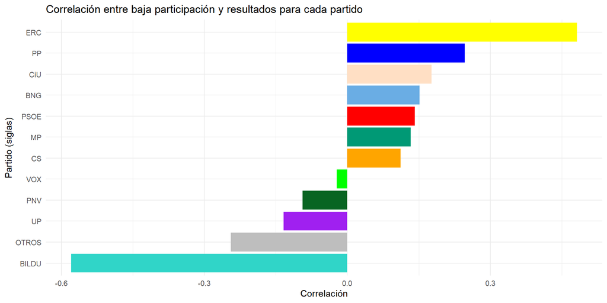

### ¿Cómo analizar la relación entre censo y voto? ¿Es cierto que determinados partidos ganan en las zonas rurales?

```r
#Media de participación en cada municipio
election_data_rcs <- election_data |>
    mutate("participacion" = 100*(votos_candidaturas + votos_blancos + votos_nulos) / censo) |> summarise(participacion=mean(participacion),
          censo=mean(censo), .by = id_mun)

calcular_anomalos <- function(datos, col) {
  Q1 <- quantile(datos[[col]], 0.25)
  Q3 <- quantile(datos[[col]], 0.75)
  IQR <- Q3 - Q1
  lim_inf <- Q1 - (IQR * 1.5)
  lim_sup <- Q3 + (IQR * 1.5)
  datos <- datos |>
  filter(censo >= lim_inf & censo <= lim_sup)
  return(datos)
}

election_data_rcs <- calcular_anomalos(election_data_rcs, "censo")
# HAGO UN CONTRASTE NO PARAMETRICO CON LA HIPÓTESIS NULA DE INDEPENDENCIA
cor.test(election_data_rcs$participacion, election_data_rcs$censo, method = "kendall")
cor.test(election_data_rcs$participacion, election_data_rcs$censo, method = "spearman")

##GRÁFICO RELACIÓN CENSO Y VOTO PARA VER LO CONTRASTADO
ggplot(election_data_rcs, aes(x = censo, y = participacion)) +
  geom_point(aes(color = participacion), size = 3, alpha = 0.7) +  # Puntos de dispersión
  geom_smooth(method = "lm", color = "black", se = TRUE, linetype = "dashed") +  # Línea de regresión
  scale_color_gradient(low = "#C0FF3E", high = "olivedrab", name = "Participación (%)")+
  labs(
    title = "Relación entre Censo y Participación",
    x = "Censo",
    y = "Participación (%)"
  ) +
  theme_minimal(base_size = 14) +
  theme(
    plot.title = element_text(face = "bold", size = 20,vjust = 0.6),  # Personalización del título
    plot.subtitle = element_text(size = 9),
    axis.title = element_text(size = 14, face = "bold"),
    legend.position = "right",
    legend.text = element_text(size = 10), # Tamaño del texto de la escala
    legend.title = element_text(size = 12),
    panel.background = element_rect(fill = "grey95"),
  )
```

### ¿Cómo analizar la relación entre censo y voto?

```
    Kendall's rank correlation tau

data:  election_data_rcs$participacion and election_data_rcs$censo
z = -18.411, p-value < 2.2e-16
alternative hypothesis: true tau is not equal to 0
sample estimates:
       tau
-0.1468109
```

```
    Spearman's rank correlation rho

data:  election_data_rcs$participacion and election_data_rcs$censo
S = 6.9324e+10, p-value < 2.2e-16
alternative hypothesis: true rho is not equal to 0
sample estimates:
       rho
-0.2163071
```

### ¿Cómo analizar la relación entre censo y voto?

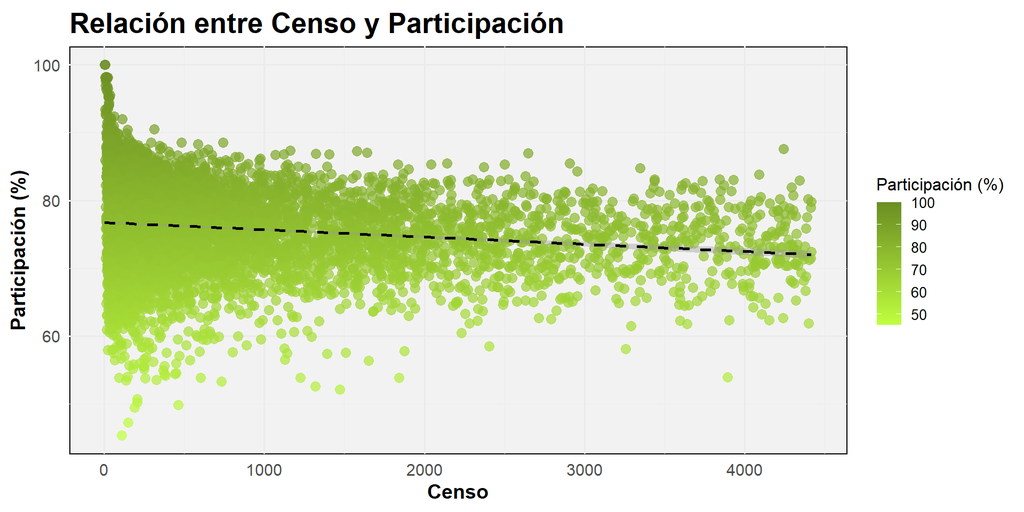

Una vez hechos los contraste de independencia se observa claramente que hay una relación de dependencia, ya que el p-valor es muy bajo. Además, esa relación también se puede observar visualmente a través del gráfico.

### ¿Es cierto que determinados partidos ganan en las zonas rurales?

```r
# Seleccionar el partido ganador por municipio y clasificar por zona
election_data <- election_data |>
  mutate(
    zona = if_else(censo <= 10000, "Rural", "Urbana")

  )

votos_por_zona <- election_data |> summarise(votos=sum(votos), .by = c(zona,siglas))

votos_por_zona2 <- votos_por_zona |> pivot_wider(names_from = zona, values_from = votos) |> mutate(porc_rural=(Rural/sum(Rural))*100, porc_urbana=(Urbana/sum(Urbana))*100, dif_perc=porc_rural-porc_urbana)

#Test de wilcoxon-MannWhitney
wilcox.test(votos_por_zona2$porc_rural, votos_por_zona2$porc_urbana, paired = TRUE)

#Gráfico de barras
barras_rural <- ggplot(votos_por_zona2) +
  geom_col(aes(x = fct_reorder(siglas, dif_perc), y= dif_perc,fill=siglas)) +
  scale_y_continuous(limits = c(-5, 5)) +
  scale_fill_manual(values= c(CS = "orange", UP = "purple", VOX = "green",
                              OTROS="grey",MP="#009975", BNG="#6AADE4",
                              PNV="#086522",CiU="#FFDFC4",ERC="yellow",
                              BILDU="#30D5C8",PSOE="red",PP="blue"))+
  theme(axis.text.x = element_text(angle = 45, hjust = 1),
        axis.title.x = element_blank(),
        legend.position = "none",
        plot.title = element_markdown( size = 13,face="bold"))+
        labs(title = "Diferencia en porcentaje en zonas rurales y urbanas y anómalos",y="DIFERENCIA (%)")

#GRAFICO CAJAS Y BIGOTES PARA LOS ANOMALOS
bigotes_rural <-ggplot(votos_por_zona2) +
  geom_boxplot(aes(y = dif_perc, fill = "#CDAA7D"), width = 0.4) +  # Una sola caja para toda la variable
  scale_y_continuous(limits = c(-5, 5)) +  # Ajuste de los límites del eje Y
  theme(
    axis.text.x = element_blank(),  # Eliminar el eje X
    axis.ticks.x = element_blank(),  # Eliminar las marcas del eje X
    axis.title.x = element_blank(),  # Eliminar el título del eje X
    axis.title.y = element_blank(),
    legend.position = "none",
  )

 barras_rural+bigotes_rural+
  plot_layout(ncol = 2, widths = c(2.75, 1.25))
```

### ¿Es cierto que determinados partidos ganan en las zonas rurales?

```
    Wilcoxon signed rank exact test

data:  votos_por_zona2$porc_rural and votos_por_zona2$porc_urbana
V = 43, p-value = 0.791
alternative hypothesis: true location shift is not equal to 0
```

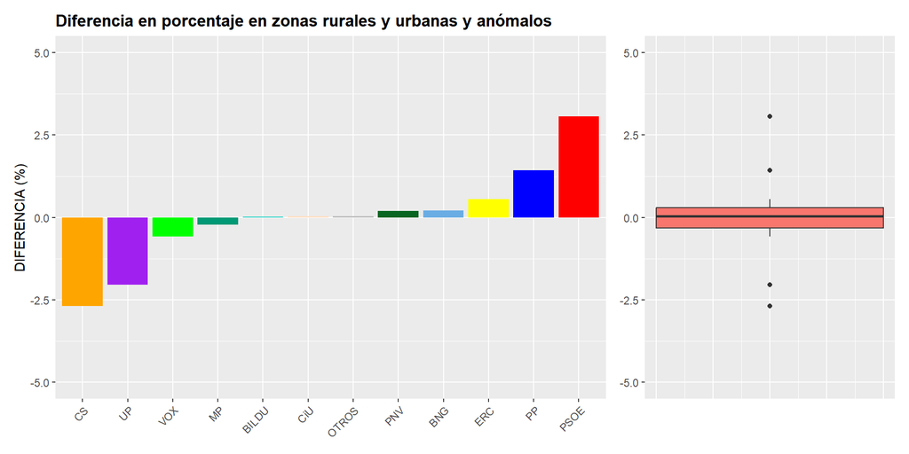

### ¿Es cierto que determinados partidos ganan en las zonas rurales?

En general, las dos muestras se posicionan de igual manera entre sí, o eso es lo que nos indica el p-valor al hacer el contraste de Wilcoxon Mann-Whitney. No obstante, eso no significa que haya individuos específicos que se salgan del promedio. Por ello, al diseñar los dos gráficos se observa que hay 4 datos anómalos que sí cambian entres poblaciones urbanas y rurales. Estos son PSOE, PP, CS y UP.

### ¿Cómo calibrar el error de las encuestas (recordemos que las encuestas son de intención de voto a nivel nacional)?

```r
# Creamos una variable en election_data y en surveys que sea la fecha de las elecciones sin el día
election_data <- election_data |>
  mutate(fecha_año_mes = format(fecha, "%Y-%m"))

surveys <- surveys |>
  mutate(fecha_año_mes = format(date_elec, "%Y-%m"))


# Calcular el total de votos por partido y el total de votantes por fecha
resultados_votos <- election_data |>
  group_by(fecha_año_mes) |>
  mutate(total_votantes = sum(votos, na.rm = TRUE)) |>   # Calcular total de votantes por fecha
  ungroup() |>
  group_by(fecha_año_mes, siglas) |>
  summarize(
    total_votos = sum(votos, na.rm = TRUE),  # Total de votos por partido
    total_votantes = first(total_votantes),  # Total de votantes por fecha
    .groups = "drop"
  )

# Unir las tablas surveys y election_data por las columnas fecha_año_mes y partido/siglas
elecciones_encuestas <- surveys |>
  inner_join(resultados_votos, by = c("fecha_año_mes" = "fecha_año_mes", "partido" = "siglas"))

# Calcular el error absoluto y relativo
elecciones_encuestas <- elecciones_encuestas |>
  mutate(error_absoluto = abs(total_votos - puntuacion * total_votantes / 100),
         error_relativo = error_absoluto /total_votantes)
```

### ¿Cómo calibrar el error de las encuestas (recordemos que las encuestas son de intención de voto a nivel nacional)?

```r
elecciones_encuestas
```

```
# A tibble: 6,420 × 16
   date_elec  id_pollster pollster media field_date_from field_date_to exit_poll
   <date>     <chr>       <chr>    <chr> <date>          <date>            <dbl>
 1 2008-03-09 pollster-49 GESOP    EL P… 2008-03-05      2008-03-07            0
 2 2008-03-09 pollster-49 GESOP    EL P… 2008-03-05      2008-03-07            0
 3 2008-03-09 pollster-49 GESOP    EL P… 2008-03-05      2008-03-07            0
 4 2008-03-09 pollster-49 GESOP    EL P… 2008-03-04      2008-03-06            0
 5 2008-03-09 pollster-49 GESOP    EL P… 2008-03-04      2008-03-06            0
 6 2008-03-09 pollster-49 GESOP    EL P… 2008-03-04      2008-03-06            0
 7 2008-03-09 pollster-49 GESOP    EL P… 2008-03-03      2008-03-05            0
 8 2008-03-09 pollster-49 GESOP    EL P… 2008-03-03      2008-03-05            0
 9 2008-03-09 pollster-49 GESOP    EL P… 2008-03-03      2008-03-05            0
10 2008-03-09 pollster-48 DEMOMÉT… TELE… 2008-02-29      2008-03-02            0
# ℹ 6,410 more rows
# ℹ 9 more variables: size <dbl>, turnout <dbl>, partido <chr>,
#   puntuacion <dbl>, fecha_año_mes <chr>, total_votos <dbl>,
#   total_votantes <dbl>, error_absoluto <dbl>, error_relativo <dbl>
```

### ¿Qué casas encuestadoras acertaron más y cuáles se desviaron más de los resultados?

```r
# Agrupar por pollster y calcular el error absoluto total y el error relativo promedio
pollster_error <- elecciones_encuestas |>
  group_by(id_pollster, pollster) |>
  summarize(
    total_error = sum(error_absoluto, na.rm = TRUE),  # Sumar el error absoluto
    avg_error_relativo = mean(error_relativo, na.rm = TRUE),  # Promedio del error relativo
    .groups = "drop"
  )

# Obtener los 5 pollsters con menor error absoluto
top_5_menor_error <- pollster_error |>
  arrange(total_error) |>   # Ordenar por error absoluto ascendente
  slice_head(n = 5)  # Seleccionar las primeras 5 filas

# Obtener los 5 pollsters con mayor error absoluto
top_5_mayor_error <- pollster_error |>
  arrange(desc(total_error)) |>   # Ordenar por error absoluto descendente
  slice_head(n = 5)  # Seleccionar las primeras 5 filas
```

### ¿Qué casas encuestadoras acertaron más y cuáles se desviaron más de los resultados?

```r
top_5_menor_error
```

```
# A tibble: 5 × 4
  id_pollster pollster   total_error avg_error_relativo
  <chr>       <chr>            <dbl>              <dbl>
1 pollster-34 TÁBULA V       563659.            0.00589
2 pollster-23 OPINA         1005838.            0.0134
3 pollster-61 CEMOP         1145364.            0.0160
4 pollster-55 APPEND        1415824.            0.0141
5 pollster-8  METRA SEIS    1720174.            0.0229
```

```r
top_5_mayor_error
```

```
# A tibble: 5 × 4
  id_pollster pollster      total_error avg_error_relativo
  <chr>       <chr>               <dbl>              <dbl>
1 pollster-43 CELESTE-TEL    481211860.             0.0261
2 pollster-58 NC REPORT      316164435.             0.0226
3 pollster-60 GAD3           260207927.             0.0178
4 pollster-79 ELECTOPANEL    244316879.             0.0198
5 pollster-56 SIMPLE LÓGICA  225880356.             0.0322
```

### 1. ¿Ha subido el peso de los grandes partidos, de los partidos nacionalistas y de los partidos nuevos a lo largo del tiempo?

```r
#Paso 1: Porcentaje de votos a cada partido por elección
election_data <- election_data |> mutate("participacion" = (votos_candidaturas + votos_blancos + votos_nulos))
participacion2 <- election_data |>
   group_by(fecha, id_mun) |>  # Agrupar por elección y municipio
  slice(1)|>
  ungroup() |>
  summarise(partic_por_elec=sum(participacion), .by = fecha)

# Paso 2: Agrupar votos por grupo y calcular el porcentaje
resultados_porcentajes <- election_data |>
  mutate(
    Grupo = case_when(
      str_detect(siglas, "PSOE|PP") ~ "PARTIDO TRADICIONAL",
      str_detect(siglas, "CS|UP|MP|VOX") ~ "PARTIDO NUEVO",
      str_detect(siglas, "PNV|BNG|ERC|BILDU|CiU") ~ "NACIONALISTA/REGIONALISTA",
      TRUE ~ "OTROS"
    )
  )
  resultados_porcentajes <- resultados_porcentajes |> summarise(n_votos = sum(votos), .by = c(fecha,Grupo)) |>
  left_join(participacion2, by = "fecha")|>  # Añadir el censo total por elección
  mutate(
    porcentaje = (n_votos / partic_por_elec) * 100  # Calcular porcentaje sobre el censo total
  )

plt1 <- ggplot(resultados_porcentajes, aes(fecha, porcentaje)) +
  geom_line(aes(color = Grupo,size= 1.2)) +
  geom_point(aes(fill = Grupo),  size = 5, pch = 21, #pch te permite tener color y borde, son ese tipo de puntos
    color = "white",
    stroke = 1 #el ancho del borde
  ) +
 scale_color_manual(values = c("#076FA1", "#2FC1D3", "#AD8C97","#C7C9CB")) +
  scale_fill_manual(values = c("#076FA1", "#2FC1D3", "#AD8C97","#C7C9CB")) +
  scale_x_date(
    breaks = unique(resultados_porcentajes$fecha),   # Usar solo las fechas específicas
    date_labels = "%Y-%b"
  ) +
  scale_y_continuous(
    breaks = seq(0, 100, by = 5),  # Intervalos de 5 unidades en el eje Y
    limits = c(0, 100))+
  theme_minimal()+
  theme(legend.position = "right")+
  theme(
    panel.background = element_rect(fill = "grey95"),#Colores de fondo para el panel y el gráfico
    plot.background = element_rect(fill = "grey95"),
    panel.grid = element_blank(), #Quitar las cuadrículas
    panel.grid.major.y = element_line(color = "#A8BAC4", size = 0.2), #Añadirlas de nuevo al eje y
    axis.ticks.length.y = unit(0, "mm"), #Quitar las marcas del eje y
    axis.ticks.length.x = unit(2, "mm"), #Dejarlas muy pequeñas en el eje x
    axis.title = element_text(size = 14, face = "bold"), # Estilo de títulos de los ejes,
    axis.line.x.bottom = element_line(color = "black"), #línea de abajo negra
    axis.text.y = element_text( size = 10), #customizar los ejes
    axis.text.x = element_text( size = 10,angle = 37,margin = margin(1.75, 0,0,0,"mm")),
    plot.title = element_markdown( size = 17,face = "bold", margin = margin(5,0,5,0))
  )+
    guides(size = "none")+
  labs(title = "Evolución de los votos por grupos (%)",y="Porcentaje de votos(%)",x="Fecha")

plt1
```

### 1. ¿Ha subido el peso de los grandes partidos, de los partidos nacionalistas y de los partidos nuevos a lo largo del tiempo?

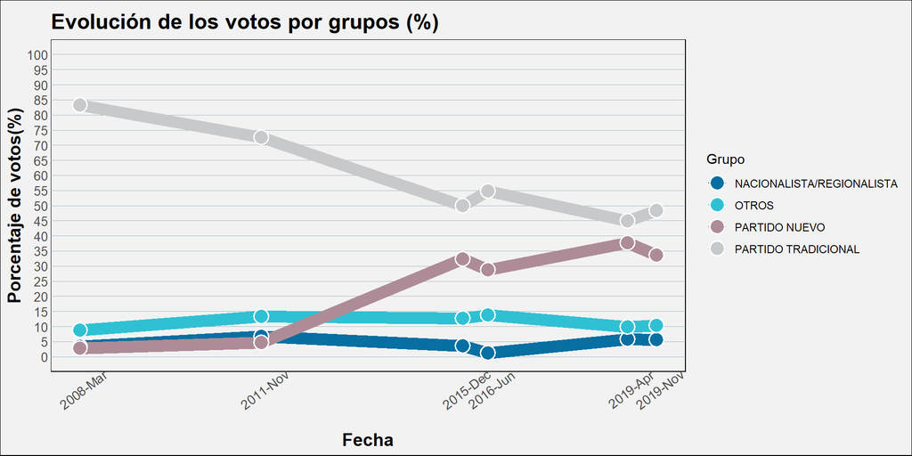

A partir del gráfico se ve como a partir de las elecciones de 2015 la irrupción de los partidos nuevos fue notables, perjudicando a los tradicionales. Ahora bien, esa bajada repentina se ha estabilizado con el paso de los años.

### 2. ¿Y los bloques?

```r
resultados_porcentajes2 <- election_data |>
  mutate(
    Grupo = case_when(
      str_detect(siglas, "VOX|PP") ~ "DERECHAS",
      str_detect(siglas, "PSOE|UP|MP") ~ "IZQUIERDAS",
      str_detect(siglas, "PNV|BNG|ERC|BILDU|CiU") ~ "NACIONALISTA/REGIONALISTA",
      str_detect(siglas, "CS") ~ "CENTRO",
      TRUE ~ "OTROS"
    )
  ) |>
  summarise(
    n_votos = sum(votos, na.rm = TRUE),   # Total de votos del grupo por elección
    .by = c(fecha,Grupo)
  ) |>
  left_join(participacion2, by = "fecha") |>  # Añadir el censo total por elección
  mutate(
    porcentaje = (n_votos / partic_por_elec) * 100  # Calcular porcentaje sobre el censo total
  )

resultados_porcentajes2 <- resultados_porcentajes2 |>
  mutate(Grupo = factor(Grupo, levels = c("DERECHAS", "CENTRO", "IZQUIERDAS",
                                          "NACIONALISTA/REGIONALISTA", "OTROS"), ordered = TRUE))|>
  arrange(fecha, Grupo)
```

### 2. ¿Y los bloques?

```r
font_add_google("Staatliches","sta")
font_add_google("Raleway","ral")
showtext_auto()

ggplot(resultados_porcentajes2, aes(fill = Grupo, values = porcentaje))+
  geom_waffle( n_rows=7, size = 0.15, colour = "white")+
  facet_wrap(~fecha,ncol=2,strip.position = "left")+
  coord_equal()+
  labs(
    title="Evolución del reparto del congreso por grupos",
  )+
  # Mostrar la leyenda
  guides(fill = guide_legend(color="white",title=NULL, label.theme = element_text(color = "white",margin = margin(0,5,0,5)))) +
  scale_fill_manual(values=c(
    "DERECHAS" = "#56B4E9",
    "IZQUIERDAS" = "#EE3B3B",
    "CENTRO" = "#E69F00",
    "NACIONALISTA/REGIONALISTA" = "#009E73",
    "OTROS" = "#999999"))+
  theme_void()+
  theme(
    plot.background = element_rect(fill="#222725"),
    plot.title = element_markdown(size=18,family='sta',margin=margin(20,0,15,0),color='white', face = "bold"),
    strip.text = element_markdown(hjust=0.5,size=15,family='ral',angle=90,lineheight = 0.45,color='white',margin= margin(0,0,3,10)))
```

### 2. ¿Y los bloques?

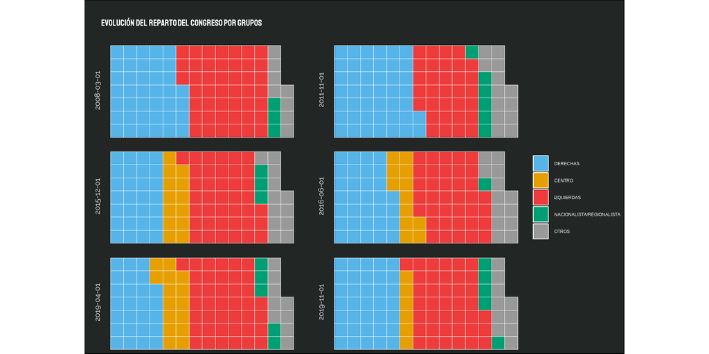

Con los bloques políticos se observa cómo la izquierda y la derecha se han ido intercambiando las mayorías a lo largo de los años. También, la entrada del centro en las escena política afectó principalmente a la derecha, pues la izquierda se mantiene igual.

### 3. ¿Existen diferencias significativas en los patrones de votos nulos, blancos y no votados entre municipios urbanos y rurales?

```r
# Crear una clasificación de municipios: Urbano o Rural
# Criterio: si el censo es mayor a 10,000, es Urbano; de lo contrario, es Rural
datos <- election_data |>
  mutate(
    tipo_municipio = ifelse(censo > 10000, "Urbano", "Rural"),
    votos_totales = votos_blancos + votos_nulos + votos_candidaturas, # Calcular total de votos
    no_votados = censo - votos_totales,
    proporción_nulos = (votos_nulos / votos_totales) * 100,          # Proporción de nulos
    proporción_blancos = (votos_blancos / votos_totales) * 100,       # Proporción de blancos
    proporción_no_votados = (no_votados / censo) * 100
  )

# Resumen de proporciones por tipo de municipio
resumen_tipo <- datos |>
  group_by(tipo_municipio) |>
  summarise(
    media_nulos = mean(proporción_nulos, na.rm = TRUE),
    media_blancos = mean(proporción_blancos, na.rm = TRUE),
    media_no_votados = mean(proporción_no_votados, na.rm = TRUE),
    .groups = "drop"
  )

# Visualización de proporciones por tipo de municipio
resumen_tipo |>
  pivot_longer(
    cols = starts_with("media"),
    names_to = "tipo_voto",
    values_to = "proporcion"
  ) |>
  mutate(
    tipo_voto = factor(tipo_voto,
                       levels = c("media_nulos", "media_blancos", "media_no_votados"))  # Fijar el orden
  ) |>
  ggplot(aes(x = tipo_municipio, y = proporcion, fill = tipo_voto)) +
  geom_col(position = "dodge") +
  scale_fill_manual(
    values = c("media_nulos" = "red",
               "media_blancos" = "blue",
               "media_no_votados" = "green"),
    labels = c("Votos Nulos", "Votos en Blanco", "No Votados")
  ) +
  labs(
    title = "Proporciones de Votos Nulos, Blancos y No Votados por Tipo de Municipio",
    x = "Tipo de Municipio",
    y = "Proporción (%)",
    fill = "Tipo de Voto"
  ) +
  theme_minimal()

# Comparación estadística: Test wilcoxon para diferencias entre Urbano y Rural
test_nulos <- wilcox.test(proporción_nulos ~ tipo_municipio, data = datos)
test_blancos <- wilcox.test(proporción_blancos ~ tipo_municipio, data = datos)
test_no_votados <- wilcox.test(proporción_no_votados ~ tipo_municipio, data = datos)

cat("Resultados del test de Wilcoxon para votos nulos:\n")
print(test_nulos)

cat("\nResultados del test de Wilcoxon para votos en blanco:\n")
print(test_blancos)

cat("\nResultados del test de Wilcoxon para no votados:\n")
print(test_no_votados)
```

### 3. ¿Existen diferencias significativas en los patrones de votos nulos, blancos y no votados entre municipios urbanos y rurales?

```
Resultados del test de Wilcoxon para votos nulos:
```

```
    Wilcoxon rank sum test with continuity correction

data:  proporción_nulos by tipo_municipio
W = 8944825598, p-value < 2.2e-16
alternative hypothesis: true location shift is not equal to 0
```

```
Resultados del test de Wilcoxon para votos en blanco:
```

```
    Wilcoxon rank sum test with continuity correction

data:  proporción_blancos by tipo_municipio
W = 7007186389, p-value < 2.2e-16
alternative hypothesis: true location shift is not equal to 0
```

```
Resultados del test de Wilcoxon para no votados:
```

```
    Wilcoxon rank sum test with continuity correction

data:  proporción_no_votados by tipo_municipio
W = 5935606127, p-value < 2.2e-16
alternative hypothesis: true location shift is not equal to 0
```

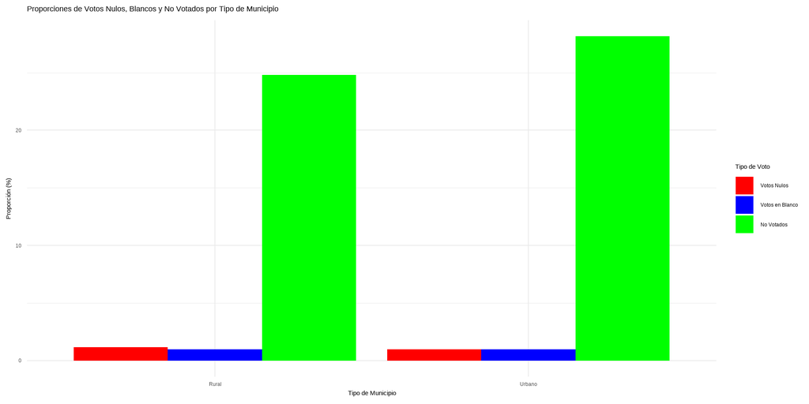

-VOTOS NULOS:

Hay diferencias significativas en la proporción de votos nulos entre municipios urbanos y rurales. Esto significa que los patrones de votos nulos son diferentes según la clasificación del municipio

-VOTOS BLANCOS:

También se observa una diferencia significativa en la proporción de votos en blanco entre municipios urbanos y rurales. Esto indica que los patrones de votos en blanco difieren entre los dos tipos de municipios.

-NO VOTADOS:

Hay una diferencia significativa en la proporción de no votados entre municipios urbanos y rurales. Esto sugiere que el nivel de abstención (personas que no votaron) varía según si el municipio es urbano o rural.

Esto indica que **los patrones de votos nulos, en blanco y no votados son significativamente diferentes entre municipios urbanos y rurales**.

# ¡Muchas gracias!

Pablo Gómez, Wenxiang Xia, Javier Figueiredo, Cyan Morales.

Entrega Grupal del Equipo 7 · Grado en Ciencia de Datos Aplicada (UCM)